# Task A

Pranav

28/03/2022

The Final Project is divided into three assignments and is presented with each question answered in its respective markdown file.

```r
rm(list = ls())
getwd()
```

```
## [1] "D:/BSE/BSE Material/sem 2/Data Vis/Project"
```

```r
setwd("D:\\BSE\\BSE Material\\sem 2\\Data Vis\\Project")

library(dplyr)
```

```r
library(ggplot2)
library(ggthemes)
                    # Install data.table package
library("data.table")
library(scales)
```

[output not shown]

A1. For the 33 London boroughs create a box-plot (or several box-plots) that compares house prices between the boroughs. Can you think of a better way to compare borough house prices (please demonstrate)?

Ans: We first filter the data according to the county of Greater London. The Data represents the 33 districts in the county and we would demonstrate the house prices according to these through a box plot.

To make our data a bit easier to visualize we undertake two steps: We first find the year from the data column and we divide the years into 3 periods 1990’s , 2000’s, 2010’s

```r
London <- pp_data %>%
  filter(county == "GREATER LONDON")
London <- London %>%
  mutate(dist = substr(district,start = 1, stop = 2))%>%
  mutate(year = as.POSIXlt(date_of_transfer)$year +1900)
head(London)
```

```
##            transaction_unique_identifier  price date_of_transfer postcode
## 1 {95ED3FE7-FFF2-4C1B-B947-6D4593D58C9B} 250000 2010-01-06 00:00  UB4 8SA
## 2 {45162B32-47C7-4CB5-8867-433D4F0B0116} 124000 1996-06-20 00:00  SM6 9LU
## 3 {BEF395C4-DDB1-4457-B18D-5DC5F7DE3C7A} 133500 1999-08-20 00:00  E14 9UW
## 4 {A2C35E07-1A0F-4A8A-9981-C2D1529A1272} 160000 2011-10-24 00:00   W6 8JS
## 5 {6A78702D-C139-4180-B731-39C1A1138357} 111500 2001-06-22 00:00  BR7 5DA
## 6 {E1AF2793-7B8A-422E-90D8-DCC54F7C9825}  78000 1995-02-15 00:00  SM1 4EQ
##   property_type old_new duration        PAON              SAON         street
## 1             S       N        F         389                   LANSBURY DRIVE
## 2             D       N        F          11                   BUCKINGHAM WAY
## 3             F       N        L          10                      UNDINE ROAD
## 4             F       N        L          29 GROUND FLOOR FLAT     BERYL ROAD
## 5             F       N        L ST MICHAELS            FLAT 3   WILLOW GROVE
## 6             S       N        F          31                       LEWIS ROAD
##      locality   town_city               district         county
## 1                   HAYES             HILLINGDON GREATER LONDON
## 2  WALLINGTON  WALLINGTON                 SUTTON GREATER LONDON
## 3                  LONDON          TOWER HAMLETS GREATER LONDON
## 4                  LONDON HAMMERSMITH AND FULHAM GREATER LONDON
## 5 CHISLEHURST CHISLEHURST                BROMLEY GREATER LONDON
## 6      SUTTON      SUTTON                 SUTTON GREATER LONDON
##   PPD_category_type record_status dist year
## 1                 A             A   HI 2010
## 2                 A             A   SU 1996
## 3                 A             A   TO 1999
## 4                 A             A   HA 2011
## 5                 A             A   BR 2001
## 6                 A             A   SU 1995
```

```r
sort(unique(London$year))
```

```
##  [1] 1995 1996 1997 1998 1999 2000 2001 2002 2003 2004 2005 2006 2007 2008 2009
## [16] 2010 2011 2012 2013 2014 2015 2016
```

```r
London <- London %>% mutate(period = case_when(year %in% seq(1995,1999,1)~"1990's",
                            year %in% seq(2000,2009,1)~"2000's",
                            year %in% seq(2010,2016,1)~"2010's"))%>%arrange(year)
  #calculate upper and lower limits
upper_limit = mean(London$price) + 2 * sd(London$price)
```

Lets First Do a Basic Box Plot, Here we remove the outliers as we assume that these are due to factors we cannot account for. For Eg (Prime residence, Luxrury Buildings, etc…). Our objective is to see the price of majority of the properties in that district

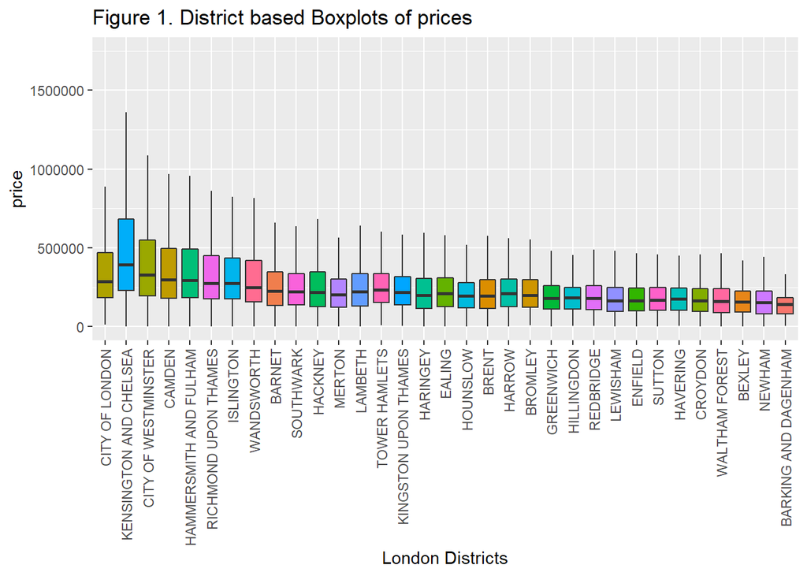

```r
District_plot <- ggplot(London,aes((x = as.factor(reorder(district, -price, na.rm = FALSE))),y= price)) +
  geom_boxplot(aes( fill = district),outlier.shape = NA)+
  ylim(0,upper_limit)+theme(legend.position="none")+scale_x_discrete(guide = guide_axis(angle = 90))+
  ggtitle("Figure 1. District based Boxplots of prices")+ xlab("London Districts")
options(repr.plot.width=12, repr.plot.height=8)
District_plot
```

The plot obtained does gives us some information about the price distribution in london district with Chelsea having the highest prices in the county. Yet these prices need to reflect their change through the decades as well as convey recent information. A better way to compare would be using the time periods data to see how these prices have differed using the same box plot but facetting it with the periods.

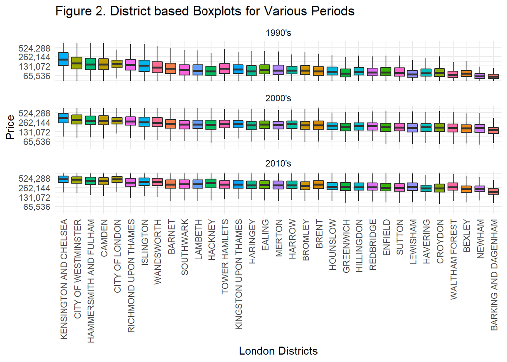

```r
Better_London <- London %>%
  filter(!price  > upper_limit)

Mod_plot <- ggplot(Better_London,aes((x = as.factor(reorder(district, -price, na.rm = FALSE))),y= price)) +
  geom_boxplot(aes( fill = district),outlier.shape = NA)+
  ylim(0,upper_limit)+theme(legend.position="none")+scale_x_discrete(guide = guide_axis(angle = 90))+
  ggtitle("Figure 1. District based Boxplots of prices")+ xlab("London Districts")+facet_wrap(~period,scales = "free_y",ncol = 1,nrow = 3)+
  scale_y_continuous(trans = "log2" , labels = scales::comma , limits = quantile(London$price, c(0.02, 0.95)))+
  ylab("Price") +
  ggtitle("Figure 2. District based Boxplots for Various Periods") +
  theme_minimal()+theme(legend.position = "none")
options(repr.plot.width=16, repr.plot.height=12)
Mod_plot
```

A2. Could the entire dataset be used to estimate the relationship between price of flats and floor level? If yes, how would you show that relationship in a plot?

Ans; Well the question is a bit tricky, firstly

```r
head(unique(London$SAON),10)
```

```
##  [1] ""                            "FLAT 1"
##  [3] "FIRST AND SECOND FLOOR FLAT" "FLAT B"
##  [5] "FLAT 51"                     "FLAT 3"
##  [7] "THE FLAT"                    "FIRST FLOOR FLAT"
##  [9] "GROUND FLOOR FLAT AT"        "FLAT 14"
```

```r
print(paste("There are",length(unique(London$SAON)),"unique values"))
```

```
## [1] "There are 4124 unique values"
```

Even there are different flats , the way the floors are labelled and the variations of these are difficult to navigate. Moreover, some do not indicate the floor they are based on. For Eg. “The Flat”, :Flat B” , Flat 14”, etc, give no indication of the floor level or any other detail which would allow us to understand the floor they are on. This limits us to labelled flats which we can segregate either through floor number or their discription. Therefore we first create a dataset which segregates flats based on SAON to find the relation between floor levels and prices of flats.

The first step involves filtering out the Flats and removing any blank spaces in the data.

```r
Flats <- pp_data%>%
  filter(property_type == "F")

Flats_mod <- Flats %>%
  filter(SAON != "")
```

Based on descriptions and floor numbers available we then segregate the data from ground to the sixth floor. Note : though there is data that indicates higher floors, we believe that ground to sixth would help in understanding if there is a trend present or not.

```r
ground <- c("BASEMENT|GROUND|LOWER")

Floor0 <- Flats_mod[grepl(ground,Flats_mod$SAON),]

Floor0["floor"] <- "ground"

first <- c("FIRST")
second <- c("SECOND")
third <- c("THIRD")
fourth <- c("FOURTH")
fifth <- c("FIFTH")
sixth <- c("SIXTH")

Floor1 <- Flats_mod[grepl(first,Flats_mod$SAON),]
Floor1["floor"] <- "first"
Floor2 <- Flats_mod[grepl(second,Flats_mod$SAON),]
Floor2["floor"] <- "second"
Floor3 <- Flats_mod[grepl(third,Flats_mod$SAON),]
Floor3["floor"] <- "third"
Floor4 <- Flats_mod[grepl(fourth,Flats_mod$SAON),]
Floor4["floor"] <- "fourth"
Floor5 <- Flats_mod[grepl(fifth,Flats_mod$SAON),]
Floor5["floor"] <- "fifth"
Floor6 <- Flats_mod[grepl(sixth,Flats_mod$SAON),]
Floor6["floor"] <- "sixth"

Floors <- rbind(Floor0,Floor1,Floor2,Floor3,Floor4,Floor5,Floor6)
```

We combine our dataset and look at the plot

```r
Floors <- Floors %>%
  mutate(year = as.POSIXlt(date_of_transfer)$year + 1900)%>%
  select(year,price,floor,SAON)

head(Floors)
```

```
##     year  price  floor                           SAON
## 2   2011 160000 ground              GROUND FLOOR FLAT
## 92  2005 164500 ground           GROUND FLOOR FLAT AT
## 124 2014 615500 ground ALL THAT FRONT BASEMENT FLAT A
## 151 2002 138500 ground              GROUND FLOOR FLAT
## 171 2015  25000 ground              GROUND FLOOR FLAT
## 190 2000 117000 ground           GROUND FLOOR FLAT AT
```

```r
tail(Floors)
```

```
##        year  price floor                     SAON
## 110757 2001 249000 sixth       SIXTH FLOOR FLAT 1
## 152258 2003 195000 sixth SIXTH FLOOR APARTMENT 19
## 197045 2003 175000 sixth SIXTH FLOOR APARTMENT 10
## 203542 2003 135500 sixth SIXTH FLOOR APARTMENT 11
## 211499 2007  87933 sixth     FLAT 14 TWOSIXTHIRTY
## 243792 1999 295000 sixth      SIXTH FLOOR FLAT 16
```

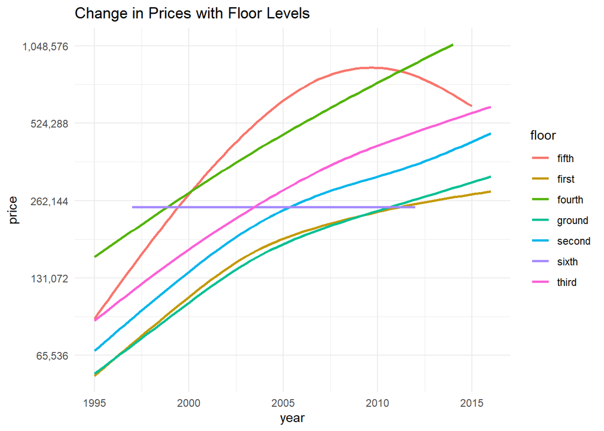

```r
floor_plot <- Floors %>%
  ggplot( aes(x=year, y=price, group=floor, color=floor)) +
  geom_smooth(method="gam", formula = y ~ s(x, bs = "cs", k=6), se = F) +
  scale_y_continuous(trans = "log2", labels = comma)+theme_minimal()+ggtitle("Change in Prices with Floor Levels")
floor_plot
```

It is key to understand that the data used considered is not uniform, for eg we get values such as FLAT 14 TWOSIXTHIRTY, when we filter for the Sixth floor, given the size of the dataset and variations of SAON values, it does not makes sense to filter outliers and distorted rows manually and we would relie on the law of large numbers.

We do see that from ground to the fourth floor there is a clear pattern of flats getting costlier. Our intial hypothesis of flats have a positive realtions therefore makes sense for this range. The data becomes unclear for floors 5 and 6 as the later shows no change with the former even though having larger values from ground to third floor , showing a dip and being lower than flats on fourth floor. These therefore contradicts our arguments further.